# Risk Factor Analysis

## Outcome Variable

**Outcome Variable:** ever_stunted

## Predictor Variables

**Intervention Variable:** mbmi

**Adjustment Set:**

- arm
- W_mage
- meducyrs
- feducyrs
- single
- brthmon
- delta_W_mage
- delta_meducyrs
- delta_feducyrs
- delta_single
- delta_brthmon

## Stratifying Variables

The analysis was stratified on these variable(s):

- agecat
- studyid
- country

## Data Summary

| agecat | studyid | country | mbmi | ever_stunted | n_cell | n |
| --- | --- | --- | --- | --- | --- | --- |
| 0-24 months | ki0047075b-MAL-ED | BANGLADESH | Normal weight | 0 | 62 | 254 |
| 0-24 months | ki0047075b-MAL-ED | BANGLADESH | Normal weight | 1 | 101 | 254 |
| 0-24 months | ki0047075b-MAL-ED | BANGLADESH | Underweight | 0 | 9 | 254 |
| 0-24 months | ki0047075b-MAL-ED | BANGLADESH | Underweight | 1 | 23 | 254 |
| 0-24 months | ki0047075b-MAL-ED | BANGLADESH | Overweight or Obese | 0 | 28 | 254 |
| 0-24 months | ki0047075b-MAL-ED | BANGLADESH | Overweight or Obese | 1 | 31 | 254 |
| 0-24 months | ki0047075b-MAL-ED | BRAZIL | Normal weight | 0 | 73 | 221 |
| 0-24 months | ki0047075b-MAL-ED | BRAZIL | Normal weight | 1 | 15 | 221 |
| 0-24 months | ki0047075b-MAL-ED | BRAZIL | Underweight | 0 | 6 | 221 |
| 0-24 months | ki0047075b-MAL-ED | BRAZIL | Underweight | 1 | 4 | 221 |
| 0-24 months | ki0047075b-MAL-ED | BRAZIL | Overweight or Obese | 0 | 92 | 221 |
| 0-24 months | ki0047075b-MAL-ED | BRAZIL | Overweight or Obese | 1 | 31 | 221 |
| 0-24 months | ki0047075b-MAL-ED | INDIA | Normal weight | 0 | 52 | 242 |
| 0-24 months | ki0047075b-MAL-ED | INDIA | Normal weight | 1 | 90 | 242 |
| 0-24 months | ki0047075b-MAL-ED | INDIA | Underweight | 0 | 20 | 242 |
| 0-24 months | ki0047075b-MAL-ED | INDIA | Underweight | 1 | 29 | 242 |
| 0-24 months | ki0047075b-MAL-ED | INDIA | Overweight or Obese | 0 | 23 | 242 |
| 0-24 months | ki0047075b-MAL-ED | INDIA | Overweight or Obese | 1 | 28 | 242 |
| 0-24 months | ki0047075b-MAL-ED | NEPAL | Normal weight | 0 | 85 | 238 |
| 0-24 months | ki0047075b-MAL-ED | NEPAL | Normal weight | 1 | 49 | 238 |
| 0-24 months | ki0047075b-MAL-ED | NEPAL | Underweight | 0 | 0 | 238 |
| 0-24 months | ki0047075b-MAL-ED | NEPAL | Underweight | 1 | 0 | 238 |
| 0-24 months | ki0047075b-MAL-ED | NEPAL | Overweight or Obese | 0 | 71 | 238 |
| 0-24 months | ki0047075b-MAL-ED | NEPAL | Overweight or Obese | 1 | 33 | 238 |
| 0-24 months | ki0047075b-MAL-ED | PERU | Normal weight | 0 | 54 | 290 |
| 0-24 months | ki0047075b-MAL-ED | PERU | Normal weight | 1 | 105 | 290 |
| 0-24 months | ki0047075b-MAL-ED | PERU | Underweight | 0 | 2 | 290 |
| 0-24 months | ki0047075b-MAL-ED | PERU | Underweight | 1 | 3 | 290 |
| 0-24 months | ki0047075b-MAL-ED | PERU | Overweight or Obese | 0 | 48 | 290 |
| 0-24 months | ki0047075b-MAL-ED | PERU | Overweight or Obese | 1 | 78 | 290 |

[output cut: 252 more lines]

The following strata were considered:

- agecat: 0-24 months, studyid: ki0047075b-MAL-ED, country: BANGLADESH
- agecat: 0-24 months, studyid: ki0047075b-MAL-ED, country: BRAZIL
- agecat: 0-24 months, studyid: ki0047075b-MAL-ED, country: INDIA
- agecat: 0-24 months, studyid: ki0047075b-MAL-ED, country: NEPAL
- agecat: 0-24 months, studyid: ki0047075b-MAL-ED, country: PERU
- agecat: 0-24 months, studyid: ki0047075b-MAL-ED, country: SOUTH AFRICA
- agecat: 0-24 months, studyid: ki0047075b-MAL-ED, country: TANZANIA, UNITED REPUBLIC OF
- agecat: 0-24 months, studyid: ki1000304b-SAS-CompFeed, country: INDIA
- agecat: 0-24 months, studyid: ki1017093-NIH-Birth, country: BANGLADESH
- agecat: 0-24 months, studyid: ki1017093b-PROVIDE, country: BANGLADESH
- agecat: 0-24 months, studyid: ki1017093c-NIH-Crypto, country: BANGLADESH
- agecat: 0-24 months, studyid: ki1066203-TanzaniaChild2, country: TANZANIA, UNITED REPUBLIC OF
- agecat: 0-24 months, studyid: ki1112895-iLiNS-Zinc, country: BURKINA FASO
- agecat: 0-24 months, studyid: ki1119695-PROBIT, country: BELARUS
- agecat: 0-24 months, studyid: ki1126311-ZVITAMBO, country: ZIMBABWE
- agecat: 0-24 months, studyid: ki1148112-LCNI-5, country: MALAWI
- agecat: 0-6 months, studyid: ki0047075b-MAL-ED, country: BANGLADESH
- agecat: 0-6 months, studyid: ki0047075b-MAL-ED, country: BRAZIL
- agecat: 0-6 months, studyid: ki0047075b-MAL-ED, country: INDIA
- agecat: 0-6 months, studyid: ki0047075b-MAL-ED, country: NEPAL
- agecat: 0-6 months, studyid: ki0047075b-MAL-ED, country: PERU
- agecat: 0-6 months, studyid: ki0047075b-MAL-ED, country: SOUTH AFRICA
- agecat: 0-6 months, studyid: ki0047075b-MAL-ED, country: TANZANIA, UNITED REPUBLIC OF
- agecat: 0-6 months, studyid: ki1000304b-SAS-CompFeed, country: INDIA
- agecat: 0-6 months, studyid: ki1017093-NIH-Birth, country: BANGLADESH
- agecat: 0-6 months, studyid: ki1017093b-PROVIDE, country: BANGLADESH
- agecat: 0-6 months, studyid: ki1017093c-NIH-Crypto, country: BANGLADESH
- agecat: 0-6 months, studyid: ki1066203-TanzaniaChild2, country: TANZANIA, UNITED REPUBLIC OF
- agecat: 0-6 months, studyid: ki1119695-PROBIT, country: BELARUS
- agecat: 0-6 months, studyid: ki1126311-ZVITAMBO, country: ZIMBABWE
- agecat: 0-6 months, studyid: ki1148112-LCNI-5, country: MALAWI
- agecat: 6-24 months, studyid: ki0047075b-MAL-ED, country: BANGLADESH
- agecat: 6-24 months, studyid: ki0047075b-MAL-ED, country: BRAZIL
- agecat: 6-24 months, studyid: ki0047075b-MAL-ED, country: INDIA
- agecat: 6-24 months, studyid: ki0047075b-MAL-ED, country: NEPAL
- agecat: 6-24 months, studyid: ki0047075b-MAL-ED, country: PERU
- agecat: 6-24 months, studyid: ki0047075b-MAL-ED, country: SOUTH AFRICA
- agecat: 6-24 months, studyid: ki0047075b-MAL-ED, country: TANZANIA, UNITED REPUBLIC OF
- agecat: 6-24 months, studyid: ki1000304b-SAS-CompFeed, country: INDIA
- agecat: 6-24 months, studyid: ki1017093-NIH-Birth, country: BANGLADESH
- agecat: 6-24 months, studyid: ki1017093b-PROVIDE, country: BANGLADESH
- agecat: 6-24 months, studyid: ki1017093c-NIH-Crypto, country: BANGLADESH
- agecat: 6-24 months, studyid: ki1066203-TanzaniaChild2, country: TANZANIA, UNITED REPUBLIC OF
- agecat: 6-24 months, studyid: ki1112895-iLiNS-Zinc, country: BURKINA FASO
- agecat: 6-24 months, studyid: ki1119695-PROBIT, country: BELARUS
- agecat: 6-24 months, studyid: ki1126311-ZVITAMBO, country: ZIMBABWE
- agecat: 6-24 months, studyid: ki1148112-LCNI-5, country: MALAWI

### Dropped Strata

Some strata were dropped due to rare outcomes:

- agecat: 0-24 months, studyid: ki0047075b-MAL-ED, country: BRAZIL
- agecat: 0-24 months, studyid: ki0047075b-MAL-ED, country: NEPAL
- agecat: 0-24 months, studyid: ki0047075b-MAL-ED, country: PERU
- agecat: 0-24 months, studyid: ki0047075b-MAL-ED, country: SOUTH AFRICA
- agecat: 0-24 months, studyid: ki0047075b-MAL-ED, country: TANZANIA, UNITED REPUBLIC OF
- agecat: 0-6 months, studyid: ki0047075b-MAL-ED, country: BRAZIL
- agecat: 0-6 months, studyid: ki0047075b-MAL-ED, country: NEPAL
- agecat: 0-6 months, studyid: ki0047075b-MAL-ED, country: PERU
- agecat: 0-6 months, studyid: ki0047075b-MAL-ED, country: SOUTH AFRICA
- agecat: 0-6 months, studyid: ki1148112-LCNI-5, country: MALAWI
- agecat: 6-24 months, studyid: ki0047075b-MAL-ED, country: BRAZIL
- agecat: 6-24 months, studyid: ki0047075b-MAL-ED, country: NEPAL
- agecat: 6-24 months, studyid: ki0047075b-MAL-ED, country: PERU
- agecat: 6-24 months, studyid: ki0047075b-MAL-ED, country: SOUTH AFRICA
- agecat: 6-24 months, studyid: ki0047075b-MAL-ED, country: TANZANIA, UNITED REPUBLIC OF

## Methods Detail

We’re interested in the causal parameters $E[Y_a]$ for all values of $a \in \mathcal{A}$. These parameters represent the mean outcome if, possibly contrary to fact, we intervened to set all units to have $A=a$. Under the randomization and positivity assumptions, these are identified by the statistical parameters $\psi_a=E_W[E_{Y|A,W}(Y|A=a,W)]$. In addition, we’re interested in the mean of $Y$, $E[Y]$ under no intervention (the observed mean). We will estimate these parameters by using SuperLearner to fit the relevant likelihood factors – $E_{Y|A,W}(Y|A=a,W)$ and $p(A=a|W)$, and then updating our likelihood fit using a joint TMLE.

For unadjusted analyses ($W=\{\}$), initial likelihoods were estimated using Lrnr_glm to estimate the simple $E(Y|A)$ and Lrnr_mean to estimate $p(A)$. For adjusted analyses, a small library containing Lrnr_glmnet, Lrnr_xgboost, and Lrnr_mean was used.

Having estimated these parameters, we will then use the delta method to estimate relative risks and attributable risks relative to a prespecified baseline level of $A$.

# Results Detail

## Results Plots

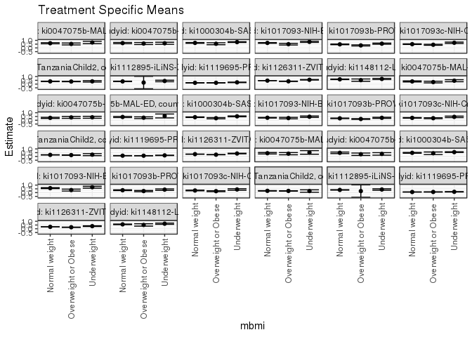

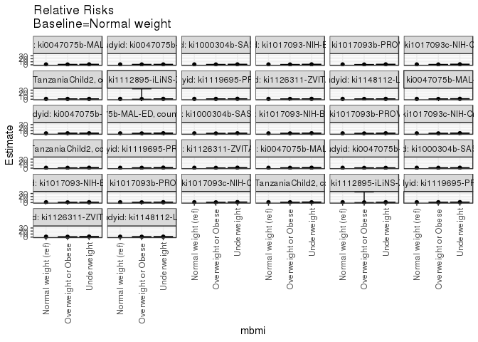

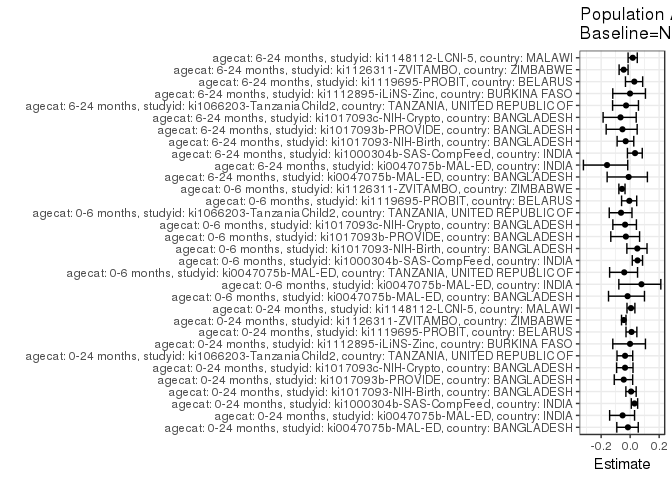

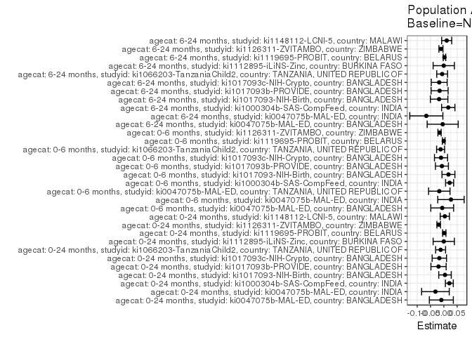

## Results Table

### Parameter: TSM

| agecat | studyid | country | intervention_level | baseline_level | estimate | ci_lower | ci_upper |
| --- | --- | --- | --- | --- | --- | --- | --- |
| 0-24 months | ki0047075b-MAL-ED | BANGLADESH | Normal weight | NA | 0.6196319 | 0.5449561 | 0.6943077 |
| 0-24 months | ki0047075b-MAL-ED | BANGLADESH | Underweight | NA | 0.7187500 | 0.5626637 | 0.8748363 |
| 0-24 months | ki0047075b-MAL-ED | BANGLADESH | Overweight or Obese | NA | 0.5254237 | 0.3977544 | 0.6530930 |
| 0-24 months | ki0047075b-MAL-ED | INDIA | Normal weight | NA | 0.6390182 | 0.5599625 | 0.7180740 |
| 0-24 months | ki0047075b-MAL-ED | INDIA | Underweight | NA | 0.6143943 | 0.4793110 | 0.7494777 |
| 0-24 months | ki0047075b-MAL-ED | INDIA | Overweight or Obese | NA | 0.5798918 | 0.4469165 | 0.7128671 |
| 0-24 months | ki1000304b-SAS-CompFeed | INDIA | Normal weight | NA | 0.6656638 | 0.6184189 | 0.7129087 |
| 0-24 months | ki1000304b-SAS-CompFeed | INDIA | Underweight | NA | 0.7708790 | 0.7243982 | 0.8173598 |
| 0-24 months | ki1000304b-SAS-CompFeed | INDIA | Overweight or Obese | NA | 0.5521818 | 0.4222537 | 0.6821099 |
| 0-24 months | ki1017093-NIH-Birth | BANGLADESH | Normal weight | NA | 0.6601372 | 0.6160467 | 0.7042276 |
| 0-24 months | ki1017093-NIH-Birth | BANGLADESH | Underweight | NA | 0.8042128 | 0.7286568 | 0.8797687 |
| 0-24 months | ki1017093-NIH-Birth | BANGLADESH | Overweight or Obese | NA | 0.4955882 | 0.3867684 | 0.6044079 |
| 0-24 months | ki1017093b-PROVIDE | BANGLADESH | Normal weight | NA | 0.4713549 | 0.4243037 | 0.5184061 |
| 0-24 months | ki1017093b-PROVIDE | BANGLADESH | Underweight | NA | 0.5620588 | 0.4872844 | 0.6368332 |
| 0-24 months | ki1017093b-PROVIDE | BANGLADESH | Overweight or Obese | NA | 0.3299613 | 0.2565513 | 0.4033713 |
| 0-24 months | ki1017093c-NIH-Crypto | BANGLADESH | Normal weight | NA | 0.4963610 | 0.4517348 | 0.5409872 |
| 0-24 months | ki1017093c-NIH-Crypto | BANGLADESH | Underweight | NA | 0.6829181 | 0.5914105 | 0.7744257 |
| 0-24 months | ki1017093c-NIH-Crypto | BANGLADESH | Overweight or Obese | NA | 0.4173807 | 0.3497569 | 0.4850045 |
| 0-24 months | ki1066203-TanzaniaChild2 | TANZANIA, UNITED REPUBLIC OF | Normal weight | NA | 0.3575285 | 0.3305378 | 0.3845191 |
| 0-24 months | ki1066203-TanzaniaChild2 | TANZANIA, UNITED REPUBLIC OF | Underweight | NA | 0.3619272 | 0.2677066 | 0.4561479 |
| 0-24 months | ki1066203-TanzaniaChild2 | TANZANIA, UNITED REPUBLIC OF | Overweight or Obese | NA | 0.3376925 | 0.3088948 | 0.3664902 |
| 0-24 months | ki1112895-iLiNS-Zinc | BURKINA FASO | Normal weight | NA | 0.3562748 | 0.3259445 | 0.3866051 |
| 0-24 months | ki1112895-iLiNS-Zinc | BURKINA FASO | Underweight | NA | 0.4102439 | 0.3100546 | 0.5104331 |
| 0-24 months | ki1112895-iLiNS-Zinc | BURKINA FASO | Overweight or Obese | NA | 0.2007645 | -0.6248005 | 1.0263296 |
| 0-24 months | ki1119695-PROBIT | BELARUS | Normal weight | NA | 0.1676722 | 0.1472004 | 0.1881439 |
| 0-24 months | ki1119695-PROBIT | BELARUS | Underweight | NA | 0.2271744 | 0.1921525 | 0.2621963 |
| 0-24 months | ki1119695-PROBIT | BELARUS | Overweight or Obese | NA | 0.1707598 | 0.1497049 | 0.1918147 |
| 0-24 months | ki1126311-ZVITAMBO | ZIMBABWE | Normal weight | NA | 0.4584502 | 0.4465439 | 0.4703564 |
| 0-24 months | ki1126311-ZVITAMBO | ZIMBABWE | Underweight | NA | 0.5696676 | 0.5324452 | 0.6068899 |
| 0-24 months | ki1126311-ZVITAMBO | ZIMBABWE | Overweight or Obese | NA | 0.3683806 | 0.3495556 | 0.3872056 |

[output cut: 66 more lines]

### Parameter: E(Y)

| agecat | studyid | country | intervention_level | baseline_level | estimate | ci_lower | ci_upper |
| --- | --- | --- | --- | --- | --- | --- | --- |
| 0-24 months | ki0047075b-MAL-ED | BANGLADESH | NA | NA | 0.6102362 | 0.5501413 | 0.6703311 |
| 0-24 months | ki0047075b-MAL-ED | INDIA | NA | NA | 0.6074380 | 0.5457864 | 0.6690897 |
| 0-24 months | ki1000304b-SAS-CompFeed | INDIA | NA | NA | 0.6863442 | 0.6430946 | 0.7295939 |
| 0-24 months | ki1017093-NIH-Birth | BANGLADESH | NA | NA | 0.6645469 | 0.6276196 | 0.7014742 |
| 0-24 months | ki1017093b-PROVIDE | BANGLADESH | NA | NA | 0.4514200 | 0.4136828 | 0.4891573 |
| 0-24 months | ki1017093c-NIH-Crypto | BANGLADESH | NA | NA | 0.4794702 | 0.4438115 | 0.5151289 |
| 0-24 months | ki1066203-TanzaniaChild2 | TANZANIA, UNITED REPUBLIC OF | NA | NA | 0.3454158 | 0.3261661 | 0.3646654 |
| 0-24 months | ki1112895-iLiNS-Zinc | BURKINA FASO | NA | NA | 0.3559962 | 0.3060347 | 0.4059578 |
| 0-24 months | ki1119695-PROBIT | BELARUS | NA | NA | 0.1692890 | 0.1503168 | 0.1882613 |
| 0-24 months | ki1126311-ZVITAMBO | ZIMBABWE | NA | NA | 0.4391486 | 0.4293319 | 0.4489653 |
| 0-24 months | ki1148112-LCNI-5 | MALAWI | NA | NA | 0.6356033 | 0.6029802 | 0.6682264 |
| 0-6 months | ki0047075b-MAL-ED | BANGLADESH | NA | NA | 0.3464567 | 0.2878227 | 0.4050907 |
| 0-6 months | ki0047075b-MAL-ED | INDIA | NA | NA | 0.3429752 | 0.2830428 | 0.4029076 |
| 0-6 months | ki0047075b-MAL-ED | TANZANIA, UNITED REPUBLIC OF | NA | NA | 0.4179688 | 0.3574314 | 0.4785061 |
| 0-6 months | ki1000304b-SAS-CompFeed | INDIA | NA | NA | 0.4269423 | 0.3929328 | 0.4609518 |
| 0-6 months | ki1017093-NIH-Birth | BANGLADESH | NA | NA | 0.3497615 | 0.3124631 | 0.3870600 |
| 0-6 months | ki1017093b-PROVIDE | BANGLADESH | NA | NA | 0.2466368 | 0.2139486 | 0.2793250 |
| 0-6 months | ki1017093c-NIH-Crypto | BANGLADESH | NA | NA | 0.3033113 | 0.2704998 | 0.3361228 |
| 0-6 months | ki1066203-TanzaniaChild2 | TANZANIA, UNITED REPUBLIC OF | NA | NA | 0.1927505 | 0.1767818 | 0.2087193 |
| 0-6 months | ki1119695-PROBIT | BELARUS | NA | NA | 0.0970280 | 0.0839943 | 0.1100616 |
| 0-6 months | ki1126311-ZVITAMBO | ZIMBABWE | NA | NA | 0.2863261 | 0.2773790 | 0.2952732 |
| 6-24 months | ki0047075b-MAL-ED | BANGLADESH | NA | NA | 0.4213836 | 0.3443902 | 0.4983771 |
| 6-24 months | ki0047075b-MAL-ED | INDIA | NA | NA | 0.4129032 | 0.3351414 | 0.4906651 |
| 6-24 months | ki1000304b-SAS-CompFeed | INDIA | NA | NA | 0.4932615 | 0.4489809 | 0.5375420 |
| 6-24 months | ki1017093-NIH-Birth | BANGLADESH | NA | NA | 0.5739130 | 0.5216565 | 0.6261696 |
| 6-24 months | ki1017093b-PROVIDE | BANGLADESH | NA | NA | 0.2997812 | 0.2577294 | 0.3418330 |
| 6-24 months | ki1017093c-NIH-Crypto | BANGLADESH | NA | NA | 0.2628458 | 0.2244546 | 0.3012371 |
| 6-24 months | ki1066203-TanzaniaChild2 | TANZANIA, UNITED REPUBLIC OF | NA | NA | 0.2280255 | 0.2072654 | 0.2487856 |
| 6-24 months | ki1112895-iLiNS-Zinc | BURKINA FASO | NA | NA | 0.3559962 | 0.3060347 | 0.4059578 |
| 6-24 months | ki1119695-PROBIT | BELARUS | NA | NA | 0.0800775 | 0.0658478 | 0.0943072 |
| 6-24 months | ki1126311-ZVITAMBO | ZIMBABWE | NA | NA | 0.2438392 | 0.2331223 | 0.2545561 |
| 6-24 months | ki1148112-LCNI-5 | MALAWI | NA | NA | 0.5983494 | 0.5626894 | 0.6340094 |

### Parameter: RR

| agecat | studyid | country | intervention_level | baseline_level | estimate | ci_lower | ci_upper |
| --- | --- | --- | --- | --- | --- | --- | --- |
| 0-24 months | ki0047075b-MAL-ED | BANGLADESH | Normal weight | Normal weight | 1.0000000 | 1.0000000 | 1.0000000 |
| 0-24 months | ki0047075b-MAL-ED | BANGLADESH | Underweight | Normal weight | 1.1599629 | 0.9048600 | 1.4869858 |
| 0-24 months | ki0047075b-MAL-ED | BANGLADESH | Overweight or Obese | Normal weight | 0.8479611 | 0.6465210 | 1.1121649 |
| 0-24 months | ki0047075b-MAL-ED | INDIA | Normal weight | Normal weight | 1.0000000 | 1.0000000 | 1.0000000 |
| 0-24 months | ki0047075b-MAL-ED | INDIA | Underweight | Normal weight | 0.9614661 | 0.7471769 | 1.2372130 |
| 0-24 months | ki0047075b-MAL-ED | INDIA | Overweight or Obese | Normal weight | 0.9074730 | 0.6991958 | 1.1777920 |
| 0-24 months | ki1000304b-SAS-CompFeed | INDIA | Normal weight | Normal weight | 1.0000000 | 1.0000000 | 1.0000000 |
| 0-24 months | ki1000304b-SAS-CompFeed | INDIA | Underweight | Normal weight | 1.1580606 | 1.0921521 | 1.2279466 |
| 0-24 months | ki1000304b-SAS-CompFeed | INDIA | Overweight or Obese | Normal weight | 0.8295205 | 0.6459998 | 1.0651773 |
| 0-24 months | ki1017093-NIH-Birth | BANGLADESH | Normal weight | Normal weight | 1.0000000 | 1.0000000 | 1.0000000 |
| 0-24 months | ki1017093-NIH-Birth | BANGLADESH | Underweight | Normal weight | 1.2182510 | 1.0857277 | 1.3669499 |
| 0-24 months | ki1017093-NIH-Birth | BANGLADESH | Overweight or Obese | Normal weight | 0.7507352 | 0.5969209 | 0.9441842 |
| 0-24 months | ki1017093b-PROVIDE | BANGLADESH | Normal weight | Normal weight | 1.0000000 | 1.0000000 | 1.0000000 |
| 0-24 months | ki1017093b-PROVIDE | BANGLADESH | Underweight | Normal weight | 1.1924324 | 1.0099423 | 1.4078972 |
| 0-24 months | ki1017093b-PROVIDE | BANGLADESH | Overweight or Obese | Normal weight | 0.7000273 | 0.5485360 | 0.8933566 |
| 0-24 months | ki1017093c-NIH-Crypto | BANGLADESH | Normal weight | Normal weight | 1.0000000 | 1.0000000 | 1.0000000 |
| 0-24 months | ki1017093c-NIH-Crypto | BANGLADESH | Underweight | Normal weight | 1.3758496 | 1.1709746 | 1.6165697 |
| 0-24 months | ki1017093c-NIH-Crypto | BANGLADESH | Overweight or Obese | Normal weight | 0.8408814 | 0.6987015 | 1.0119937 |
| 0-24 months | ki1066203-TanzaniaChild2 | TANZANIA, UNITED REPUBLIC OF | Normal weight | Normal weight | 1.0000000 | 1.0000000 | 1.0000000 |
| 0-24 months | ki1066203-TanzaniaChild2 | TANZANIA, UNITED REPUBLIC OF | Underweight | Normal weight | 1.0123032 | 0.7719661 | 1.3274646 |
| 0-24 months | ki1066203-TanzaniaChild2 | TANZANIA, UNITED REPUBLIC OF | Overweight or Obese | Normal weight | 0.9445191 | 0.8428368 | 1.0584688 |
| 0-24 months | ki1112895-iLiNS-Zinc | BURKINA FASO | Normal weight | Normal weight | 1.0000000 | 1.0000000 | 1.0000000 |
| 0-24 months | ki1112895-iLiNS-Zinc | BURKINA FASO | Underweight | Normal weight | 1.1514815 | 0.9200187 | 1.4411770 |
| 0-24 months | ki1112895-iLiNS-Zinc | BURKINA FASO | Overweight or Obese | Normal weight | 0.5635104 | 0.0092154 | 34.4579951 |
| 0-24 months | ki1119695-PROBIT | BELARUS | Normal weight | Normal weight | 1.0000000 | 1.0000000 | 1.0000000 |
| 0-24 months | ki1119695-PROBIT | BELARUS | Underweight | Normal weight | 1.3548721 | 1.1672621 | 1.5726359 |
| 0-24 months | ki1119695-PROBIT | BELARUS | Overweight or Obese | Normal weight | 1.0184145 | 0.9285137 | 1.1170197 |
| 0-24 months | ki1126311-ZVITAMBO | ZIMBABWE | Normal weight | Normal weight | 1.0000000 | 1.0000000 | 1.0000000 |
| 0-24 months | ki1126311-ZVITAMBO | ZIMBABWE | Underweight | Normal weight | 1.2425944 | 1.1582482 | 1.3330828 |
| 0-24 months | ki1126311-ZVITAMBO | ZIMBABWE | Overweight or Obese | Normal weight | 0.8035347 | 0.7588093 | 0.8508962 |

[output cut: 66 more lines]

### Parameter: PAR

| agecat | studyid | country | intervention_level | baseline_level | estimate | ci_lower | ci_upper |
| --- | --- | --- | --- | --- | --- | --- | --- |
| 0-24 months | ki0047075b-MAL-ED | BANGLADESH | Normal weight | NA | -0.0093957 | -0.0544586 | 0.0356672 |
| 0-24 months | ki0047075b-MAL-ED | INDIA | Normal weight | NA | -0.0315802 | -0.0834957 | 0.0203352 |
| 0-24 months | ki1000304b-SAS-CompFeed | INDIA | Normal weight | NA | 0.0206804 | 0.0058771 | 0.0354838 |
| 0-24 months | ki1017093-NIH-Birth | BANGLADESH | Normal weight | NA | 0.0044097 | -0.0191156 | 0.0279351 |
| 0-24 months | ki1017093b-PROVIDE | BANGLADESH | Normal weight | NA | -0.0199349 | -0.0485019 | 0.0086322 |
| 0-24 months | ki1017093c-NIH-Crypto | BANGLADESH | Normal weight | NA | -0.0168908 | -0.0439187 | 0.0101371 |
| 0-24 months | ki1066203-TanzaniaChild2 | TANZANIA, UNITED REPUBLIC OF | Normal weight | NA | -0.0121127 | -0.0308208 | 0.0065954 |
| 0-24 months | ki1112895-iLiNS-Zinc | BURKINA FASO | Normal weight | NA | -0.0002786 | -0.0402429 | 0.0396858 |
| 0-24 months | ki1119695-PROBIT | BELARUS | Normal weight | NA | 0.0016169 | -0.0046963 | 0.0079300 |
| 0-24 months | ki1126311-ZVITAMBO | ZIMBABWE | Normal weight | NA | -0.0193016 | -0.0260261 | -0.0125771 |
| 0-24 months | ki1148112-LCNI-5 | MALAWI | Normal weight | NA | 0.0037061 | -0.0135851 | 0.0209973 |
| 0-6 months | ki0047075b-MAL-ED | BANGLADESH | Normal weight | NA | -0.0061138 | -0.0489312 | 0.0367037 |
| 0-6 months | ki0047075b-MAL-ED | INDIA | Normal weight | NA | 0.0267680 | -0.0227590 | 0.0762950 |
| 0-6 months | ki0047075b-MAL-ED | TANZANIA, UNITED REPUBLIC OF | Normal weight | NA | -0.0170595 | -0.0572437 | 0.0231247 |
| 0-6 months | ki1000304b-SAS-CompFeed | INDIA | Normal weight | NA | 0.0216955 | 0.0066664 | 0.0367246 |
| 0-6 months | ki1017093-NIH-Birth | BANGLADESH | Normal weight | NA | 0.0172823 | -0.0069959 | 0.0415606 |
| 0-6 months | ki1017093b-PROVIDE | BANGLADESH | Normal weight | NA | -0.0072450 | -0.0316708 | 0.0171807 |
| 0-6 months | ki1017093c-NIH-Crypto | BANGLADESH | Normal weight | NA | -0.0105649 | -0.0351878 | 0.0140580 |
| 0-6 months | ki1066203-TanzaniaChild2 | TANZANIA, UNITED REPUBLIC OF | Normal weight | NA | -0.0121078 | -0.0272068 | 0.0029913 |
| 0-6 months | ki1119695-PROBIT | BELARUS | Normal weight | NA | -0.0005405 | -0.0056049 | 0.0045238 |
| 0-6 months | ki1126311-ZVITAMBO | ZIMBABWE | Normal weight | NA | -0.0161254 | -0.0222022 | -0.0100486 |
| 6-24 months | ki0047075b-MAL-ED | BANGLADESH | Normal weight | NA | -0.0043589 | -0.0626452 | 0.0539274 |
| 6-24 months | ki0047075b-MAL-ED | INDIA | Normal weight | NA | -0.0658202 | -0.1279619 | -0.0036785 |
| 6-24 months | ki1000304b-SAS-CompFeed | INDIA | Normal weight | NA | 0.0166439 | -0.0083180 | 0.0416059 |
| 6-24 months | ki1017093-NIH-Birth | BANGLADESH | Normal weight | NA | -0.0177241 | -0.0505756 | 0.0151274 |
| 6-24 months | ki1017093b-PROVIDE | BANGLADESH | Normal weight | NA | -0.0159066 | -0.0478667 | 0.0160536 |
| 6-24 months | ki1017093c-NIH-Crypto | BANGLADESH | Normal weight | NA | -0.0174184 | -0.0472860 | 0.0124493 |
| 6-24 months | ki1066203-TanzaniaChild2 | TANZANIA, UNITED REPUBLIC OF | Normal weight | NA | -0.0063885 | -0.0266950 | 0.0139180 |
| 6-24 months | ki1112895-iLiNS-Zinc | BURKINA FASO | Normal weight | NA | -0.0003084 | -0.0403042 | 0.0396875 |
| 6-24 months | ki1119695-PROBIT | BELARUS | Normal weight | NA | 0.0023103 | -0.0025287 | 0.0071493 |
| 6-24 months | ki1126311-ZVITAMBO | ZIMBABWE | Normal weight | NA | -0.0109106 | -0.0184457 | -0.0033755 |
| 6-24 months | ki1148112-LCNI-5 | MALAWI | Normal weight | NA | 0.0107535 | -0.0081630 | 0.0296701 |

### Parameter: PAF

| agecat | studyid | country | intervention_level | baseline_level | estimate | ci_lower | ci_upper |
| --- | --- | --- | --- | --- | --- | --- | --- |
| 0-24 months | ki0047075b-MAL-ED | BANGLADESH | Normal weight | NA | -0.0153968 | -0.0920297 | 0.0558585 |
| 0-24 months | ki0047075b-MAL-ED | INDIA | Normal weight | NA | -0.0519892 | -0.1414193 | 0.0304340 |
| 0-24 months | ki1000304b-SAS-CompFeed | INDIA | Normal weight | NA | 0.0301313 | 0.0080219 | 0.0517480 |
| 0-24 months | ki1017093-NIH-Birth | BANGLADESH | Normal weight | NA | 0.0066357 | -0.0294112 | 0.0414203 |
| 0-24 months | ki1017093b-PROVIDE | BANGLADESH | Normal weight | NA | -0.0441603 | -0.1095622 | 0.0173865 |
| 0-24 months | ki1017093c-NIH-Crypto | BANGLADESH | Normal weight | NA | -0.0352281 | -0.0932408 | 0.0197062 |
| 0-24 months | ki1066203-TanzaniaChild2 | TANZANIA, UNITED REPUBLIC OF | Normal weight | NA | -0.0350670 | -0.0906847 | 0.0177145 |
| 0-24 months | ki1112895-iLiNS-Zinc | BURKINA FASO | Normal weight | NA | -0.0007825 | -0.1196793 | 0.1054888 |
| 0-24 months | ki1119695-PROBIT | BELARUS | Normal weight | NA | 0.0095509 | -0.0285577 | 0.0462475 |
| 0-24 months | ki1126311-ZVITAMBO | ZIMBABWE | Normal weight | NA | -0.0439523 | -0.0594084 | -0.0287216 |
| 0-24 months | ki1148112-LCNI-5 | MALAWI | Normal weight | NA | 0.0058308 | -0.0217529 | 0.0326699 |
| 0-6 months | ki0047075b-MAL-ED | BANGLADESH | Normal weight | NA | -0.0176466 | -0.1491280 | 0.0987908 |
| 0-6 months | ki0047075b-MAL-ED | INDIA | Normal weight | NA | 0.0780464 | -0.0779828 | 0.2114917 |
| 0-6 months | ki0047075b-MAL-ED | TANZANIA, UNITED REPUBLIC OF | Normal weight | NA | -0.0408152 | -0.1416358 | 0.0511016 |
| 0-6 months | ki1000304b-SAS-CompFeed | INDIA | Normal weight | NA | 0.0508160 | 0.0147663 | 0.0855467 |
| 0-6 months | ki1017093-NIH-Birth | BANGLADESH | Normal weight | NA | 0.0494118 | -0.0226036 | 0.1163556 |
| 0-6 months | ki1017093b-PROVIDE | BANGLADESH | Normal weight | NA | -0.0293753 | -0.1334110 | 0.0651109 |
| 0-6 months | ki1017093c-NIH-Crypto | BANGLADESH | Normal weight | NA | -0.0348318 | -0.1193053 | 0.0432664 |
| 0-6 months | ki1066203-TanzaniaChild2 | TANZANIA, UNITED REPUBLIC OF | Normal weight | NA | -0.0628157 | -0.1440178 | 0.0126226 |
| 0-6 months | ki1119695-PROBIT | BELARUS | Normal weight | NA | -0.0055711 | -0.0590830 | 0.0452371 |
| 0-6 months | ki1126311-ZVITAMBO | ZIMBABWE | Normal weight | NA | -0.0563185 | -0.0777673 | -0.0352965 |
| 6-24 months | ki0047075b-MAL-ED | BANGLADESH | Normal weight | NA | -0.0103443 | -0.1585883 | 0.1189315 |
| 6-24 months | ki0047075b-MAL-ED | INDIA | Normal weight | NA | -0.1594082 | -0.3222514 | -0.0166202 |
| 6-24 months | ki1000304b-SAS-CompFeed | INDIA | Normal weight | NA | 0.0337426 | -0.0186777 | 0.0834654 |
| 6-24 months | ki1017093-NIH-Birth | BANGLADESH | Normal weight | NA | -0.0308829 | -0.0898699 | 0.0249116 |
| 6-24 months | ki1017093b-PROVIDE | BANGLADESH | Normal weight | NA | -0.0530606 | -0.1653563 | 0.0484142 |
| 6-24 months | ki1017093c-NIH-Crypto | BANGLADESH | Normal weight | NA | -0.0662683 | -0.1864336 | 0.0417262 |
| 6-24 months | ki1066203-TanzaniaChild2 | TANZANIA, UNITED REPUBLIC OF | Normal weight | NA | -0.0280166 | -0.1210257 | 0.0572758 |
| 6-24 months | ki1112895-iLiNS-Zinc | BURKINA FASO | Normal weight | NA | -0.0008662 | -0.1198718 | 0.1054930 |
| 6-24 months | ki1119695-PROBIT | BELARUS | Normal weight | NA | 0.0288503 | -0.0323144 | 0.0863910 |
| 6-24 months | ki1126311-ZVITAMBO | ZIMBABWE | Normal weight | NA | -0.0447453 | -0.0761189 | -0.0142863 |
| 6-24 months | ki1148112-LCNI-5 | MALAWI | Normal weight | NA | 0.0179720 | -0.0141917 | 0.0491157 |